# Generalized Additive Models (GAM) with GeD Splines

Emilio Luis Sáenz Guillén

2026-07-16

## Introduction

GeDS methodology is implemented on the **R** package GeDS. In this post I will focus in introducing the **GAM-GeDS** implementation. If interested in the canonical GeDS methodology please check [Geometrically Designed Splines: `GeDS`](https://rpubs.com/emilioluissaenzguillen/1273496).

## What are Generalized Additive Models?

You are probably familiar with linear regression. Let’s do a quick review of some concepts.

### Linear Regression and GLM

**Multiple linear regression model (MLR)** is used to study the relationship between a dependent/response/outcome variable $Y$ and one or more independent/predictor/explanatory variables $X_1,..., X_P$. In particular, we assume that there is a linear relationship between the population mean of the outcome variable $Y$ and the value of the explanatory variables $X_1,..., X_P$:
$$\begin{align}
&\mathbb{E}\left[Y\right] = \alpha + \sum_{j=1}^P\beta_jX_j
\quad\text{or}\quad Y = \alpha + \sum_{j=1}^P\beta_jX_j +
\varepsilon&&
\end{align}$$
where the response $Y$ and the error $\varepsilon$ are random variables, while the covariates $X_j, \; j = 1,...,P,$ are assumed to be deterministic. The MLR model relies on four major assumptions ([Rencher & Schaalje 2008](https://onlinelibrary.wiley.com/doi/book/10.1002/9780470192610), [Montgomery et al. 2021](https://www.wiley.com/en-gb/Introduction+to+Linear+Regression+Analysis%2C+6th+Edition-p-9781119578758)):

**A1.** The relationship between the response $Y$ and the regressors $X_1,...,X_P$ is linear.

**A2.** The error term has zero mean, $\mathbb{E}\left[\varepsilon\right]=0$, or, equivalently, $\mathbb{E}\left[Y\right] = \alpha + \sum_{j=1}^P\beta_jX_j$.

**A3.** The error term has constant variance, $\mathbb{E}\left[\varepsilon^2\right]=\sigma^2$, or, equivalently, $\text{Var}(Y) =\sigma^2$.

**A4.** The errors are uncorrelated, $\text{Cov}\left(\varepsilon_i, \varepsilon_j\right) = 0,\;\forall i\neq j$, or, equivalently, $\text{Cov}\left(Y_i, Y_j\right) = 0,\;\forall i\neq j$.

And since we are often interested in testing hypotheses and constructing confidence intervals about the model parameters, an additional assumption is often included:

**A5.** The errors are normally distributed.

To sum up, we assume that the relation between $Y$ and $X_1,...,X_P$ is linear, that $\varepsilon \sim \mathcal{N}(0,\sigma^2)$ —or $Y \sim \mathcal{N}(\alpha + \sum_{j=1}^P\beta_jX_j,\sigma^2)$—, and that the errors are uncorrelated with each other. Jointly normally distributed random variables are independent if they are uncorrelated, and thus, instead of **A4**, it is also common to see instead the assumption that “errors are independent of each other”, i.e., $\varepsilon_i,\varepsilon_j$ are independent $\forall i\neq j$, or, equivalently, $Y_i,Y_j$ are independent $\forall i\neq j$. Given a sample $\{Y_i,X_i\}_{i=1}^N$, estimates of $\beta_0, \beta_1,...,\beta_P$ are usually obtained using the least squares method. If assumptions **A1**-**A4** hold then, by the Gauss-Markov theorem, the least-squares estimators $\beta_1,...\beta_P$ are best linear unbiased estimators (BLUE). If **A5** is also satisfied, LS coincides with the maximum likelihood estimator (MLE).

**Generalized linear models (GLM)** extend linear models to accommodate data from any distribution belonging to the exponential family, which, for example, includes the Normal, Poisson, Binomial or Gamma distributions. A GLM relates the conditional mean of the response variable to the linear predictor function via an invertible link function $g$:
$$\begin{align}
&g\left(\mathbb{E}\left[Y\right]\right) =
\beta_0+\beta_1X_1+\beta_2X_2+...+\beta_PX_P
&&
\end{align}$$

### Additive models and GAM

**Additive models (AM)** extend MLR by allowing for the incorporation of nonlinear smooth functions of the covariates:
$$\begin{align}
&\mathbb{E}\left[Y|X_1,..., X_P\right] = \alpha+\sum_{j=1}^P
f_j(X_j)
\quad\text{or}\quad Y = \alpha + \sum_{j=1}^P f_j(X_j) +\varepsilon
&&
\end{align}$$
where the error term $\varepsilon$ is assumed to have zero mean, $\mathbb{E}\left[\varepsilon\right]=0$, constant variance, $\mathbb{E}\left[\varepsilon^2\right]=\sigma^2$, and to be independent of the predictor variables $X_1,...,X_P$. It is also implicitly assumed that $\mathbb{E}\left[f_j\left(X_j\right)\right]=0$ (which implies $\mathbb{E}\left[Y\right]=\alpha$), since otherwise there would be unaccounted constants in each of the functions $f_j$ ([Hastie & Tibshirani 1990](https://www.taylorfrancis.com/books/mono/10.1201/9780203753781/generalized-additive-models-hastie)).

**Generalized additive models (GAM)** extend GLM in a similar way, i.e., by replacing each linear component $\beta_jX_j$ with a smooth non-linear function $f_j(X_j)$, in order to allow for non-linear predictor effects. In other words, GAM extend AM by allowing the response variable to follow any distribution from the exponential family.

$$\begin{align}
g(\mathbb{E}\left[Y|X_1,...,X_P\right]) = \alpha + \sum_{j=1}^P
f_j(X_j), \quad\quad \mathbb{E}\left[f_j(X_j)\right] = 0,\quad j=1,...,P
\end{align}$$

### Generalized Additive Models fitting: Local-Scoring and Backfitting

[Hastie & Tibshirani 1990](https://www.taylorfrancis.com/books/mono/10.1201/9780203753781/generalized-additive-models-hastie), propose the *local scoring* algorithm in conjunction with the *backfitting* algorithm to fit GAM.

#### 1. Backfitting

One can fit an AM by means of the backfitting algorithm:

**Algorithm 1**: Backfitting Algorithm for Additive Models

1. Initialize: $\hat{\alpha}=\frac{1}{N}\sum_{i=1}^NY_i$, $\hat{f}_j= 0$, $\forall j$
2. For each base-learner $\hat{f}_j$, $j=1,...,P$
   $$\begin{align}
   &\hat{f}_j \leftarrow S_j\left[\left\{Y_i-\hat{\alpha}-\sum_{k\neq
   j}\hat{f}_k\left(X_{ik}\right)\right\}_{i=1}^N\right]\\
   &\hat{f}_j \leftarrow \hat{f}_j
   -\frac{1}{N}\sum_{i=1}^N\hat{f}_j(X_{ij})
   \end{align}$$
   for $S_j$ being some arbitrary scatterplot smoother (i.e. some regression fitting model).
3. Repeat Step 2 until
   $$\begin{align}
   \text{RSS}=\sum_{i=1}^N\left(Y_i-\hat{\alpha}-\sum_{j=1}^Pf_j(X_{ij})\right)^2
   \end{align}$$
   fails to decrease.

#### 2. Local Scoring

For fitting GAM, the local scoring algorithm is proposed:

**Algorithm 2**: Local Scoring Algorithm for Generalized Additive Models

1. $\hat{\alpha}=g\left(\frac{1}{N}\sum_{i=1}^NY_i\right)$, $\hat{f}_j^0=0$, $j=1,...,P$, and $m=0$.
2. Set $m=m+1$ and iterate to form the predictor $\boldsymbol{\hat{\eta}}$, the mean $\boldsymbol{\hat{\mu}}$, the weights $\boldsymbol{w}$, and the adjusted dependent variable $\boldsymbol{z}$:
- Form the adjusted dependent variable
  $$\begin{align}
  & z_i = \hat{\eta}^{(m-1)}_i+\left(Y_i - \hat{\mu}^{(m-1)}_i
  \right)\cdot\left(\frac{\partial\hat{\eta}}{\partial\hat{\mu}}\right)_i^{(m-1)}
  \end{align}$$
  where, $\hat{\eta}^{(m-1)}_i = \hat{\alpha} + \sum_{j=1}^P \hat{f}_j^{(m-1)}(X_{ij})$ and $\hat{\mu}^{(m-1)}_i = g^{-1}\left(\hat{\eta}^{(m-1)}_i\right)$
- Form the weights: $w_ i = \left(V^{(m-1)}_ i\right)^{-1}\cdot \left[\left(\frac{\partial\hat{\mu}}{\partial \hat{\eta} }\right)_ i^{(m-1)}\right]^2$ where $V_i^{(m-1)}$ is the variance of $Y$ at $\hat{\mu}_i^{(m-1)}$.
- Fit an additive model to $\boldsymbol{z}$ by using the backfitting algorithm with weights $\boldsymbol{w}$ to obtain the estimated functions $\hat{f}_j^{(m)}(\cdot)$, $j=1,...P$, and the model $\boldsymbol{\hat{\eta}^m}$.
3. The empirical deviance $\sum_{i=1}^N\text{dev}\left(Y_i,\hat{\mu}^m_i\right)$ fails to decrease.

Note that if `family = "gaussian"` the local scoring algorithm stems to straight implementation of backfitting.

## Generalized Additive Models with GeD Splines

Our GAM-GeDS implementation involves applying the local scoring algorithm, using Normal GeD splines as the function smoothers to estimate $f_j$ within the backfitting algorithm.

```r
# install.packages("GeDS")
library("GeDS")
```

Let us illustrate the GAM-GeDS technique by using the `car.test.frame` dataset. The `car.test.frame` data frame has 60 rows and 8 columns, giving data on makes of cars taken from the April, 1990 issue of *Consumer Reports* ([Therneau & Atkinson 2023](https://CRAN.R-project.org/package=rpart)). The variables are:

- `Price`: price in US dollars of a standard model
- `Country` of origin: a factor with levels `France`, `Germany`, `Japan`, `Japan/USA`, `Korea`, `Mexico`, `Sweden` and `USA`.
- `Reliability`: a numeric vector coded 1 to 5.
- `Mileage`: fuel consumption in (US) miles per gallon (mpg).
- `Type`: a factor with levels `Compact`, `Large`, `Medium`, `Small`, `Sporty`, and `Van`.
- `Weight`: kerb weight in pounds.
- `Disp.`: the engine capacity (displacement) in liters.
- `HP`: net horsepower of the vehicle.

```r
library(rpart)
car_data <- car.test.frame
Gmodgam <- NGeDSgam(Mileage ~ f(Price) + Country + Type + f(Weight) + f(Disp.) + f(HP),
                    data = car_data, phi = 0.95)
```

```
## f(Weight) has less than 2 linear internal knots.
## f(Disp.) has less than 2 linear internal knots. Quadratic averaging knot location is not computed for base learners with less than 2 internal knots.
## f(Weight) has less than 3 linear internal knots.
## f(Disp.) has less than 3 linear internal knots. Cubic averaging knot location is not computed for base learners with less than 3 internal knots.
```

The above messages inform us that no internal knot was fit for `Weight`, i.e. the GeDS learner considered that a straight line fit was the best option for this predictor. Hence, no averaging knot location is computed for this covariate (see Stage B in [Geometrically Designed Splines:`GeDS`](https://rpubs.com/emilioluissaenzguillen/1186169)). For `Disp.` only one internal knot was fit, hence, the averaging knot location for the quadratic and cubic fits is not computed. Note we relax the defaul GeDS stopping rule by setting `phi = 0.95` (instead of `phi = 0.9`).

First, we can extract the coefficients of the linear/quadratic/cubic GeDS-GAM fits (not displayed for conciseness):

```r
# Linear GAM-GeDS Fit
coef(Gmodgam, n = 2)
# Quadratic GAM-GeDS Fit
coef(Gmodgam, n = 3)
# Cubic GAM-GeDS Fit
coef(Gmodgam, n = 4)
```

The coefficients for the linear fit are provided in piecewise polynomial form, while for the quadratic and cubic fits are given in B-spline form.

Second, the knots can be extracted as follows:

```r
# Linear GAM-GeDS Fit
knots(Gmodgam, n = 2)
```

```
## $`f(Price)`
## [1]  5866.000  5866.000  7169.350  7960.505 11902.291 20465.167 24760.000
## [8] 24760.000
##
## $Country
## NULL
##
## $Type
## NULL
##
## $`f(Weight)`
## [1] 1845 1845 3855 3855
##
## $`f(Disp.)`
## [1]  73.0000  73.0000 227.0536 305.0000 305.0000
##
## $`f(HP)`
## [1]  63.00000  63.00000  88.56865 116.65251 147.35135 225.00000 225.00000
```

```r
# Quadratic GAM-GeDS Fit
knots(Gmodgam, n = 3)
```

```
## $`f(Price)`
## [1]  5866.000  5866.000  5866.000  7564.928  9931.398 16183.729 24760.000
## [8] 24760.000 24760.000
##
## $Country
## NULL
##
## $Type
## NULL
##
## $`f(Weight)`
## [1] 1845 1845 1845 3855 3855 3855
##
## $`f(Disp.)`
## [1]  73.0000  73.0000  73.0000 227.0536 305.0000 305.0000 305.0000
##
## $`f(HP)`
## [1]  63.0000  63.0000  63.0000 102.6106 132.0019 225.0000 225.0000 225.0000
```

```r
# Cubic GAM-GeDS Fit
knots(Gmodgam, n = 4)
```

```
## $`f(Price)`
##  [1]  5866.000  5866.000  5866.000  5866.000  9010.715 13442.654 24760.000
##  [8] 24760.000 24760.000 24760.000
##
## $Country
## NULL
##
## $Type
## NULL
##
## $`f(Weight)`
## [1] 1845 1845 1845 1845 3855 3855 3855 3855
##
## $`f(Disp.)`
## [1]  73.0000  73.0000  73.0000  73.0000 227.0536 305.0000 305.0000 305.0000
## [9] 305.0000
##
## $`f(HP)`
## [1]  63.0000  63.0000  63.0000  63.0000 117.5242 225.0000 225.0000 225.0000
## [9] 225.0000
```

where note that the $n$ left and right most knots are assumed coalescent.

Third, we can extract the deviances, which in this case (family = “gaussian”) are the Residual Sum of Squares (RSS):

```r
# Linear GAM-GeDS Fit
deviance(Gmodgam, n = 2)
```

```
## [1] 146.871
```

```r
# Quadratic GAM-GeDS Fit
deviance(Gmodgam, n = 3)
```

```
## [1] 81.61975
```

```r
# Cubic GAM-GeDS Fit
deviance(Gmodgam, n = 4)
```

```
## [1] 70.37585
```

The components of a GAM-GeDS object can be plotted in the linear predictor scale as follows:

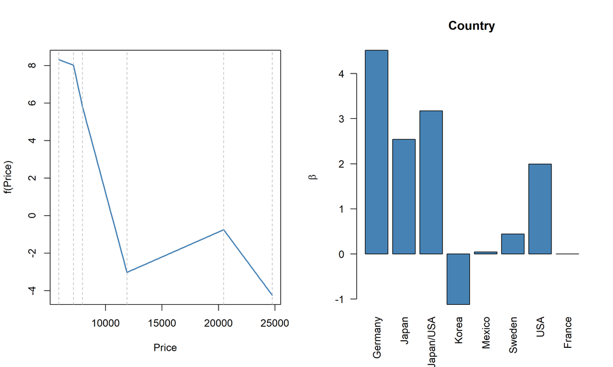

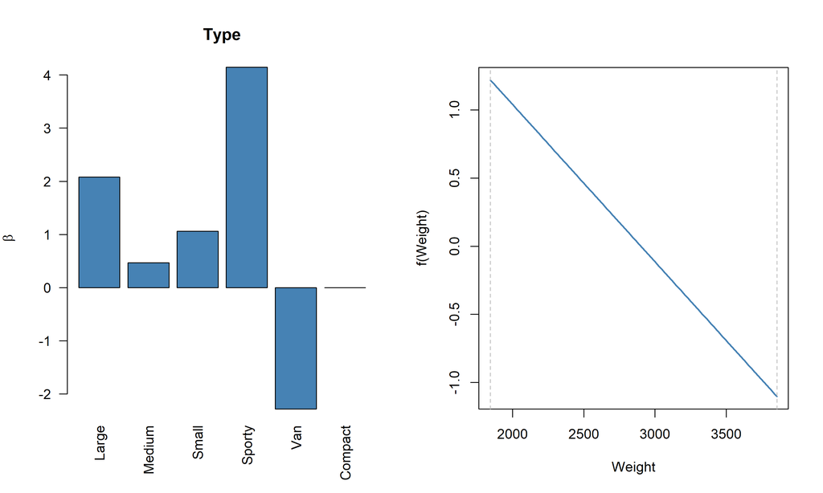

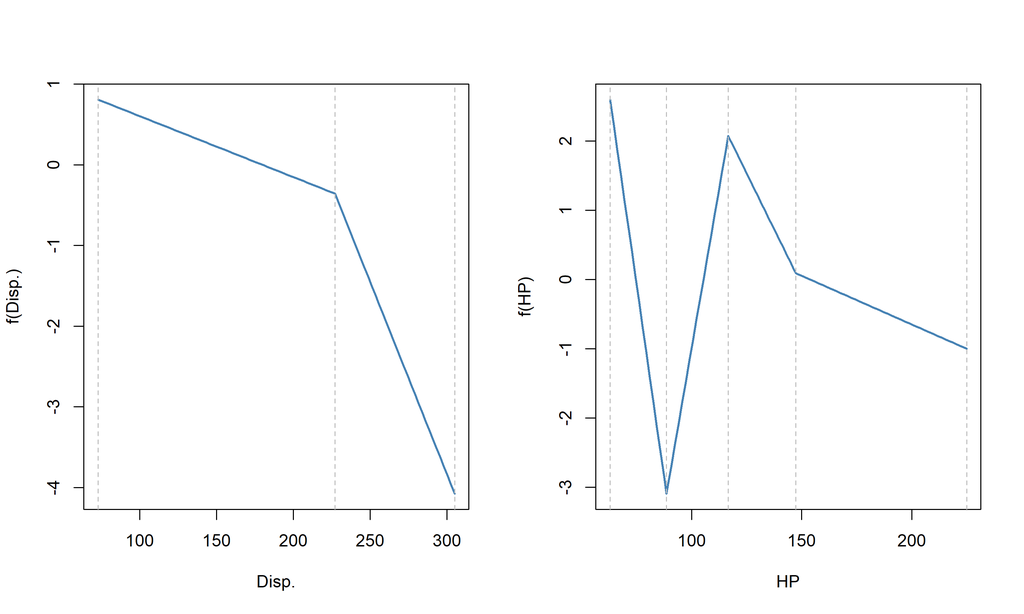

```r
# Linear GAM-GeDS Fit
layout(matrix(c(1,2), nrow=1, byrow=TRUE))
plot(Gmodgam, n = 2, col = "steelblue")
```

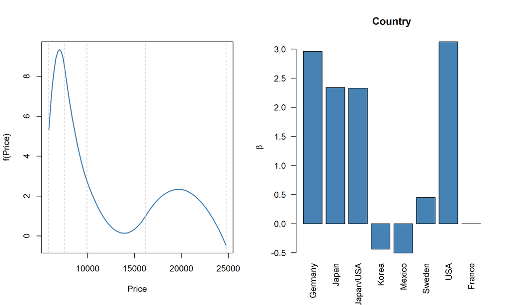

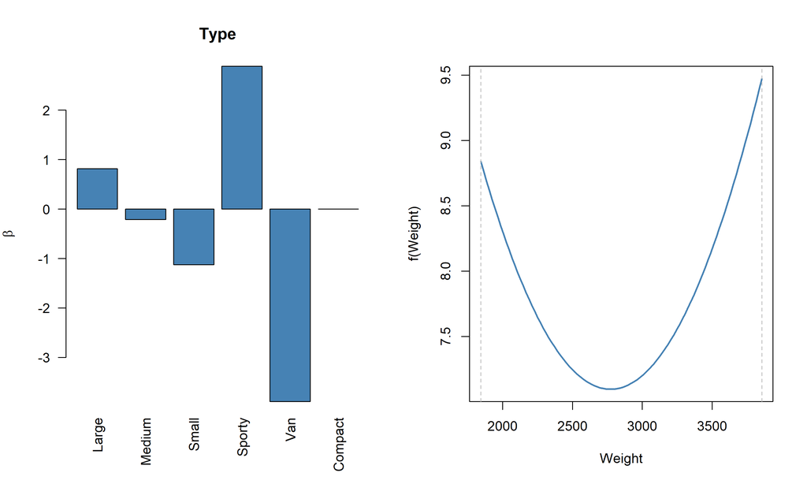

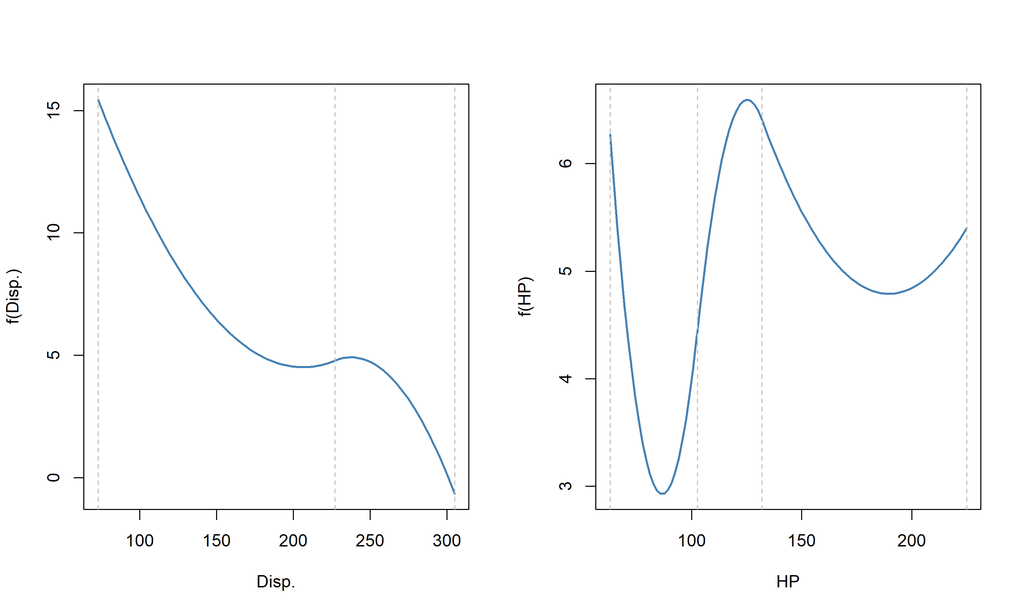

```r
# Quadratic GAM-GeDS Fit
layout(matrix(c(1,2), nrow=1, byrow=TRUE))
plot(Gmodgam, n = 3, col = "steelblue")
```

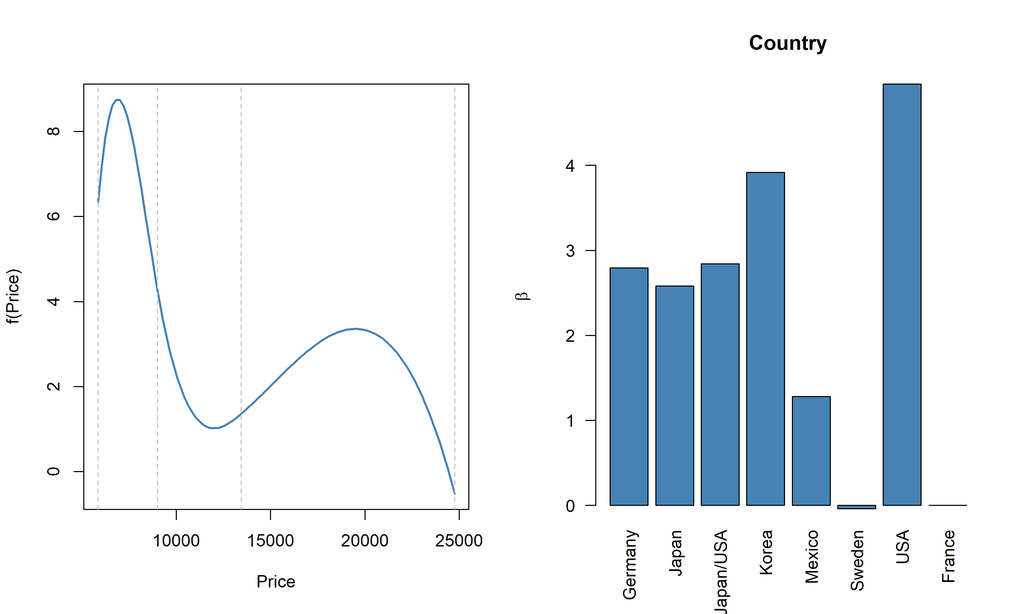

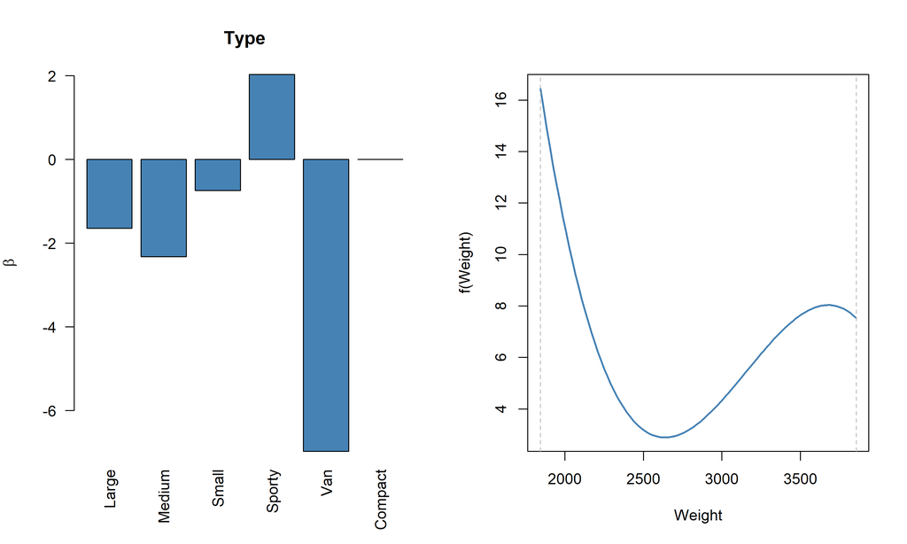

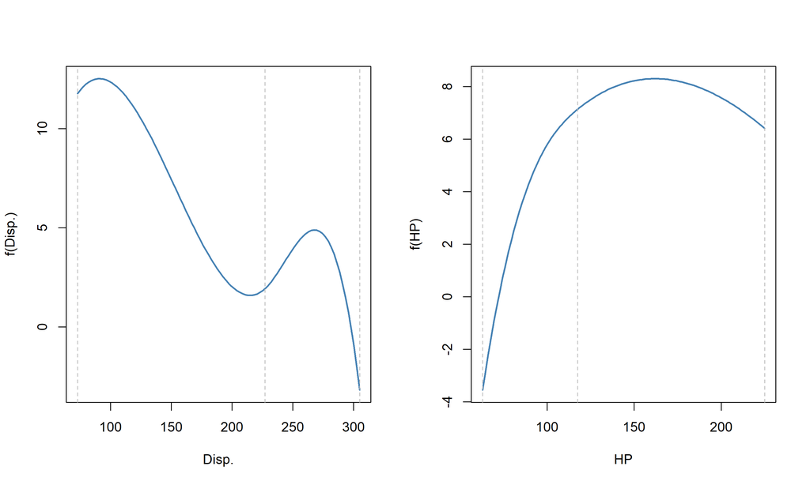

```r
# Cubic GAM-GeDS Fit
layout(matrix(c(1,2), nrow=1, byrow=TRUE))
plot(Gmodgam, n = 4, col = "steelblue")
```

For each fit, for each learner, the corresponding knots location is traced with vertical dotted lines.

To assess the model’s accuracy on unseen data we can proceed as follows:

```r
# Set seed for reproducibility
set.seed(123)
# Determine the size of the dataset
n <- nrow(car_data)
# Create a random sample of row indices for the training set
trainIndex <- sample(1:n, size = floor(0.8 * n))
# Subset the data into training and test sets
train <- car_data[trainIndex, ]
test <- car_data[-trainIndex, ]

Gmodgam <- NGeDSgam(Mileage ~ f(Price) + Country + Type + f(Weight) + f(Disp.) + f(HP),
                    data = train, phi = 0.9)
```

The truth is more likely to be smooth than wiggly, hence we reduce further `phi`. We compute predictions on the test sample and calculate the corresponding mean squared error for each fit:

```r
mean((test$Mileage - predict(Gmodgam, newdata = test, n = 2))^2)
```

```
## [1] 2.060389
```

```r
mean((test$Mileage - predict(Gmodgam, newdata = test, n = 3))^2)
```

```
## [1] 14.47061
```

```r
mean((test$Mileage - predict(Gmodgam, newdata = test, n = 4))^2)
```

```
## [1] 11.32994
```

To conclude, let us move to the actual GAM context by considering the modelling of `Price` instead. A widely used distribution for pricing models is `Gamma`.

```r
Gmodgam <- NGeDSgam(Price ~ f(Mileage) + Country + Type + f(Weight) + f(Disp.) + f(HP),
                    data = train, family = Gamma(link=log), phi = 0.9)
```

And we calculate the Gamma deviance on the test set as follows:

[output not shown]

Dimitrova, D. S., Kaishev, V. K., Lattuada, A., & Verrall, R. J. (2023). Geometrically designed variable knot splines in generalized (non-)linear models. *Applied Mathematics and Computation*, *436*. https://doi.org/10.1016/j.amc.2022.127493

Hastie, T. J., & Tibshirani, R. J. (1990). Generalized additive models. *Monographs on Statistics and Applied Probability. Chapman & Hall*, *43*, 335.

Kaishev, V. K., Dimitrova, D. S., Haberman, S., & Verrall, R. J. (2016). Geometrically designed, variable knot regression splines. *Computational Statistics*, *31*(3), 1079–1105. https://doi.org/10.1007/s00180-015-0621-7

Montgomery, D. C., Peck, E. A., & Vining, G. G. (2021). *Introduction to linear regression analysis*. John Wiley & Sons.

Rencher, A. C., & Schaalje, G. B. (2008). *Linear models in statistics*. John Wiley & Sons.

Therneau, T., & Atkinson, B. (2023). *Rpart: Recursive partitioning and regression trees*. https://CRAN.R-project.org/package=rpart